# 2016-02 : 전산통계학 - About Delay

LEEJONGWON

03 12월, 2016, 12:16

## Basic Setup : SparkR, library, Data Reading

R MarkDown으로 실행시 chunk가 전부 실행되는 단점이 존재한다. 따라서 많은 시간이 걸리기 때문에, saveDf.r을 먼저 실행 시킨 후, 결과를 따로 저장한다. R MarkDown에서 결과를 활용하여 요약 및 시각화하는 목적이 있다.

## Analysis of Airline Dealy

공항을 이용하는 사람들은 지연시간에 대해 민감하다. 물론 지연시간 몇분이 공항을 선택하는 주요 요소가 되지는 않는다. 하지만, 공항을 이용하는 고객들에게 지연시간은 신경써야하는 요소임에 틀림없다. 따라서 1987.10 ~ 2008.12 미국 항공 데이터를 이용하여 지연시간에 대해 탐구했다.

## 기초 통계량

지연시간 탐구에 앞서 데이터를 이해하는 과정이 필요하다. 따라서 관련된 기초 통계량을 확인하였다.

#### 총 운행횟수

```r
  total_flight = "123534969"
  print( paste(total_flight, "회 운행") )
```

```
## [1] "123534969 회 운행"
```

#### 항공기 운행에 이용된 공항의 총 갯수

```r
    originDf = `OriginDf.csv`
    print( paste(length(unique(originDf$Origin)), "대의 공항이 이용됨.") )
```

```
## [1] "347 대의 공항이 이용됨."
```

#### 출발 및 도착의 지연시간

```r
  delay_df = `delay_df.csv`
  print( paste("도착 지연시간 :", round(sum(delay_df$ArrDelaySum,na.rm = T)/sum(delay_df$CNT,na.rm = T),2) , "분" ) )
```

```
## [1] "도착 지연시간 : 6.9 분"
```

```r
  print( paste("출발 지연시간 :", round(sum(delay_df$DepDealySum,na.rm = T)/sum(delay_df$CNT,na.rm = T),2 ), "분" ) )
```

```
## [1] "출발 지연시간 : 8.02 분"
```

```r
  head(delay_df, n = 15)
```

```
##     X Year     CNT ArrDelaySum DepDealySum
## 1   1 1990 5270893    35428621    36056469
## 2   2 2003 6488540    22931403    33520821
## 3   3 2007 7453215    74151049    83127865
## 4   4 2006 7141922    60812894    70857247
## 5   5 1988 5202096    33636991    34552818
## 6   6 1997 5411843    39715039    43764457
## 7   7 1994 5180048    28885504    34054230
## 8   8 2004 7129270    45476603    55258141
## 9   9 1991 5076925    23780907    28961203
## 10 10 1989 5041200    41630119    40743704
## 11 11 1996 5351983    50391291    52187849
## 12 12 1998 5384721    39657467    47290612
## 13 13 1987 1311826    12170428    10419357
## 14 14 1995 5327435    36701002    43343726
## 15 15 2001 5967780    31641888    46780894
```

## 공항의 연도별 지연시간의 변화

공항을 기준으로 지연시간에 대한 탐색을 했다. 공항기준 지연시간이란 다음과 같다. 해당 공항의 총 Delay는 출발지가 해당 공항일때의 DepDelay와 도착지가 해당 공항일때의 ArrDelay를 함께 고려한다.

#### 연간 Arrival & Departure 평균 지연시간 및 운행횟수

공항별 평균 지연시간과 운행횟수를 얻었습니다.

```r
  airports_df = `airports_df.csv`
  airportsDelay = `airportsDelay.csv`
  head(airportsDelay, n = 10)
```

```
##     X Year    CNT DepDelaySum ArrDelaySum DepDelayMean ArrDelayMean
## 1   1 1987  49460      477201      519896     9.648221    10.511444
## 2   2 1988 196069     1712540     1613634     8.734374     8.229929
## 3   3 1989 179616     1760988     1782884     9.804182     9.926087
## 4   4 1990 184780     1574168     1515991     8.519147     8.204302
## 5   5 1991 179845     1331991     1060958     7.406328     5.899291
## 6   6 1992 182862     1496272     1348629     8.182520     7.375119
## 7   7 1993 184653     1828794     1746309     9.903950     9.457247
## 8   8 1994 192715     1868751     1616355     9.696967     8.387282
## 9   9 1995 179875     1693266     1290582     9.413571     7.174883
## 10 10 1996 177554     1992221     1931926    11.220367    10.880780
##    airports
## 1       BOS
## 2       BOS
## 3       BOS
## 4       BOS
## 5       BOS
## 6       BOS
## 7       BOS
## 8       BOS
## 9       BOS
## 10      BOS
```

#### 공항별 delayMean과 depMean의 boxplot

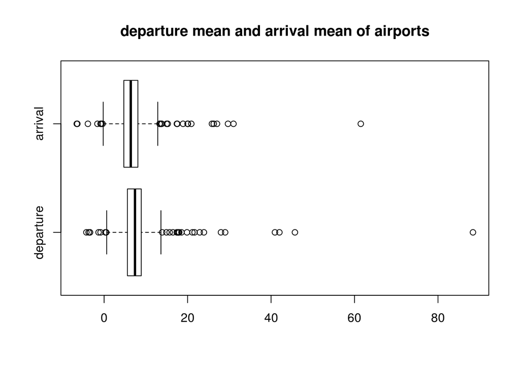

```r
    delaySummary = `delaySummary.csv`
    boxplot(delaySummary$depMean, delaySummary$arrMean, horizontal = TRUE,
            main = "departure mean and arrival mean of airports", names = c("departure", "arrival") )
```

#### 공항별 delayMean과 depMean의 boxplot

boxplot을 확인한 결과 dealy평균이 20분 이상인 데이터는 상식에 맞지 않는 데이터라고 생각했다. 따라서 Delay가 20분 이상인 공항에 대해서 확인하고, 이를 제외하여 boxplot을 다시 그렸다.

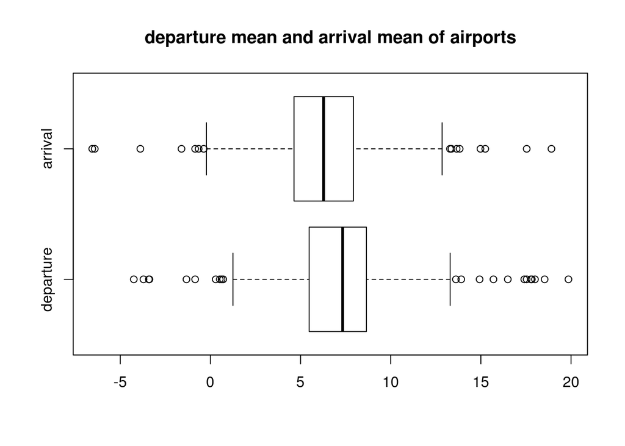

```r
    boxplot(delaySummary[!delaySummary$airports %in% over20,]$depMean,
            delaySummary[!delaySummary$airports %in% over20,]$arrMean, horizontal = TRUE,
            main = "departure mean and arrival mean of airports", names = c("departure", "arrival") )
```

## xyplot

미국의 거점 공항과 탐색한 outlier에 대한 공항별 연도 / Delay의 그래프를 나타내었다. 미국의 거점 공항의 출처는 다음과 같다.(https://ko.wikipedia.org/wiki/%EA%B5%AD%EC%A0%9C%EA%B3%B5%ED%95%AD) outlier중 공항 운행횟수가 극히 적은(under 100) 공항은 평균치에 그 의미가 적으므로 제외한다.

#### 도착지연시간의 xyplot

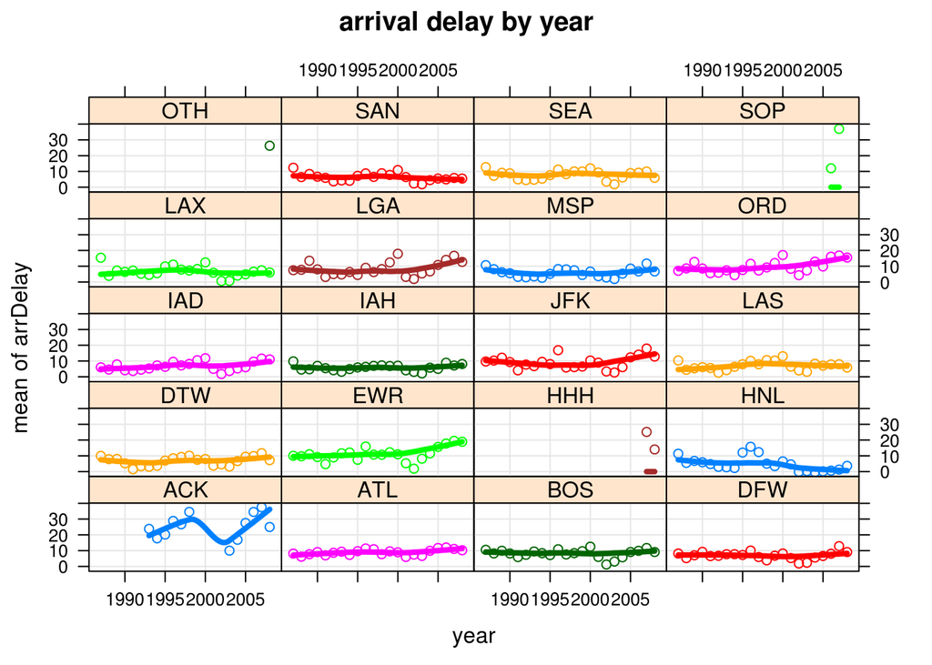

```r
  over20Genuine = unique(airportsDelay[airportsDelay$airports %in% over20 & airportsDelay$CNT > 100,]$airports)
  targetAirports <- c( c("JFK", "LAX", "ATL", "BOS", "DFW", "DTW", "EWR", "IAD", "IAH", "LAS",
                         "LGA", "MSP", "ORD", "SEA" , "SAN", "HNL"), over20Genuine)
  res_df = airportsDelay[airportsDelay$airports %in% targetAirports,]

  # 도착지연시간
  suppressWarnings(xyplot(res_df$ArrDelayMean ~ res_df$Year | res_df$airports, group=res_df$airports, grid=TRUE,
                        layout=c(4,5), type = c("p", "smooth"), lwd = 4, lattice.options = list(panel.error = "warning"),
                        xlab="year", ylab="mean of arrDelay", main = "arrival delay by year"))
```

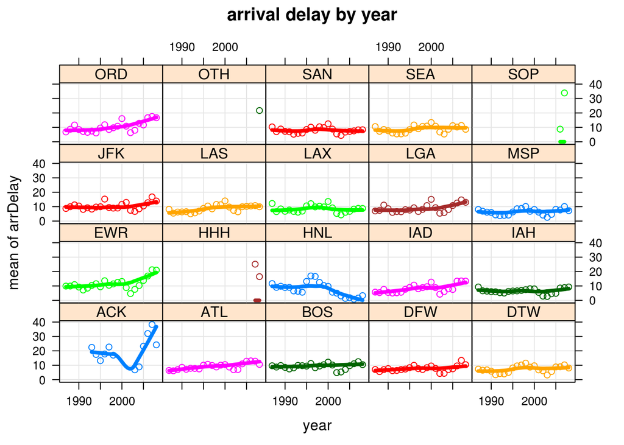

```r
  # 출발지연시간
  suppressWarnings(xyplot(res_df$DepDelayMean ~ res_df$Year | res_df$airports, group=res_df$airports, grid=TRUE,
                        type = c("p", "smooth"), lwd = 4, lattice.options = list(panel.error = "warning"),
                        xlab="year", ylab="mean of arrDelay", main = "arrival delay by year"))
```

평균이 20분이 넘는 OTH, HHH, SOP, ACK 공항에서는 Delay Mean이 높은 모습을 확인할 수 있다. 각각의 공항에서는 운항횟수의 문제와 더불어 운항 노선도 적은 모습을 알 수 있었다.

##### Example : ACK 공항

ACK 공항에서는 JFK, EWR 등의 적은 노선만이 확인된다.

```r
    ACKdf = `ACKdf.csv`
    head(ACKdf, n = 15)
```

```
##     X Year Dest DepDelayMean ArrDelayMean
## 1   1 1998  EWR    26.850000    37.800000
## 2   2 2006  EWR    33.511962    38.878049
## 3   3 1995  EWR    31.388889    37.000000
## 4   4 2008  JFK    31.643902    30.034146
## 5   5 2007  JFK    55.090909    29.022727
## 6   6 2007  EWR    47.937931    61.675862
## 7   7 1993  EWR    16.684211    18.947368
## 8   8 2004  EWR    13.753488    21.070093
## 9   9 1996  EWR    14.454545    13.272727
## 10 10 2008  EWR    28.140187    27.233645
## 11 11 1997  EWR    24.266667    21.333333
## 12 12 2005  EWR    22.079208    32.065000
## 13 13 2003  EWR     7.212766     8.176471
## 14 14 1994  EWR    13.100000    15.900000
## 15 15 1995  LGA     7.300000    16.650000
```

## 국제 공항의 15분 이상 delay된 비율

국제 공항의 15분 이상 delay된 비율을 지도에 표시하였다. 대표적인 국제공항은 총 16개로 나타나지만, 뉴욕의 EWR, JFK 그리고 워싱턴의 IAD의 2008년의 자료를 활용하였다.

##### EWR 공항의 depDelay

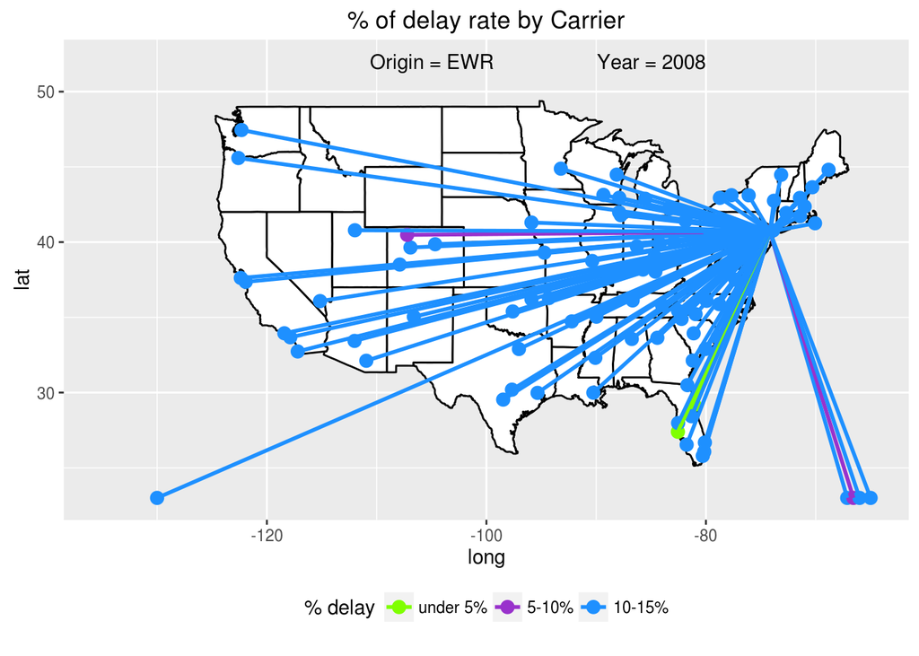

```r
  EWR_map1 = getMap("EWR", 2008, arrDelay = FALSE)
  print(EWR_map1$map)
```

##### EWR 공항의 arrDelay

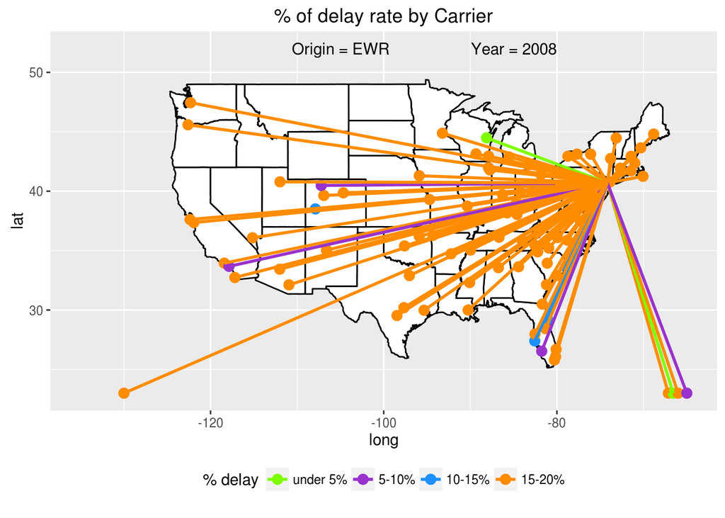

```r
  EWR_map2 = getMap("EWR", 2008, arrDelay = TRUE)
  print(EWR_map2$map)
```

2008년의 EWR는 위와 같은 양상이다. EWR에서는 depDelay는 arrDelay보다 적은 양상을 띈다. 게다가 대부분의 지역에서 높은 delay가 발생한 모습을 확인할 수 있다.

##### JFK 공항의 depDelay

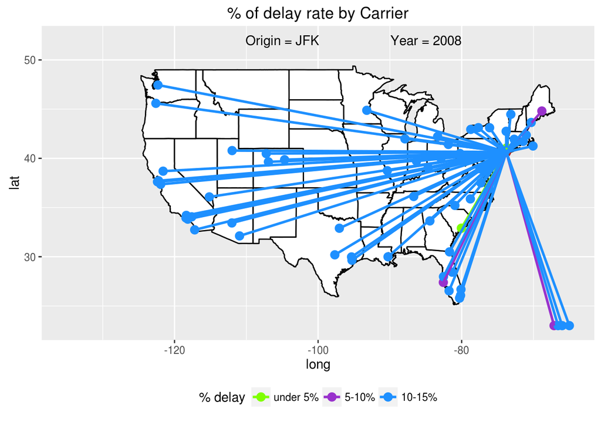

```r
  JFK_map1 = getMap("JFK", 2008, arrDelay = FALSE)
  print(JFK_map1$map)
```

##### JFK 공항의 arrDelay

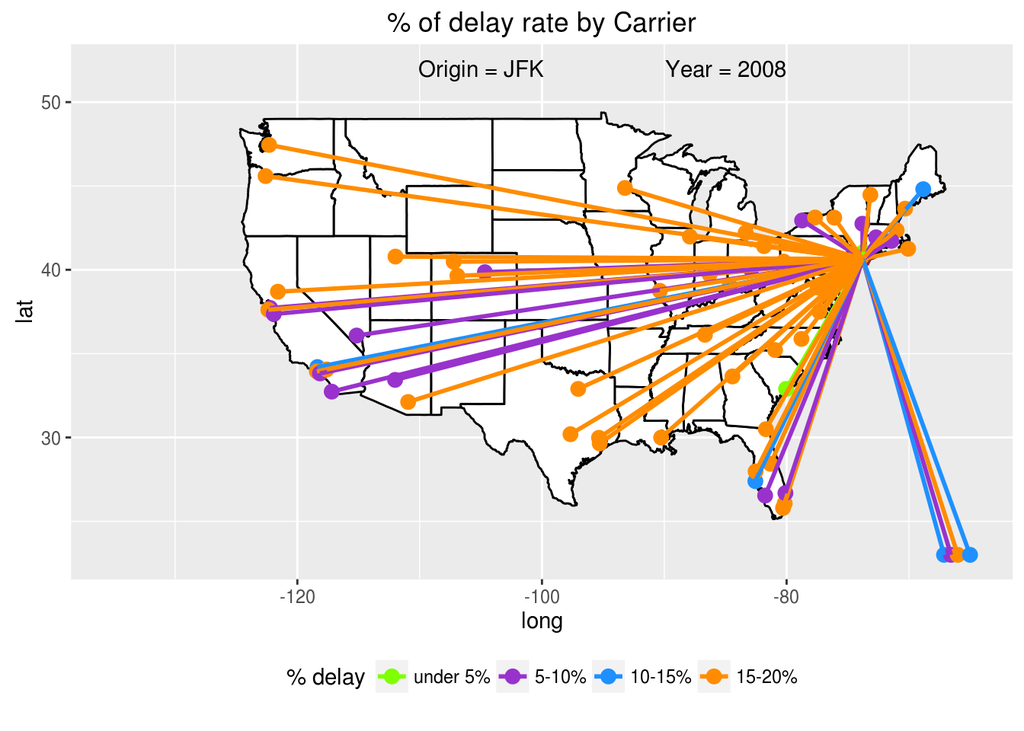

```r
  JFK_map2 = getMap("JFK", 2008, arrDelay = TRUE)
  print(JFK_map2$map)
```

2008년의 JFK는 위와 같은 양상이다. JFK역시 NewYork발 depDelay는 arrDelay보다 적은 양상을 띈다. 하지만 arrDelay는 그 양상이 EWR보다는 delay가 적은 모습을 보인다.

##### IAD 공항의 depDelay

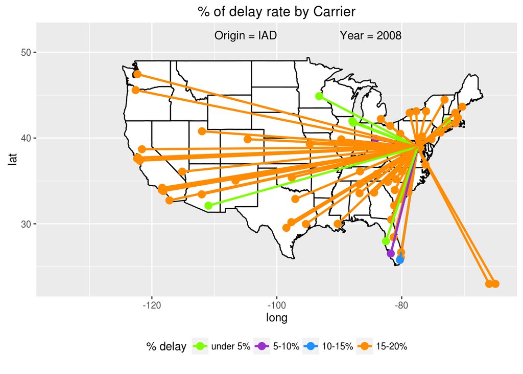

```r
  IAD_map1 = getMap("IAD", 2008, arrDelay = FALSE)
  print(IAD_map1$map)
```

##### IAD 공항의 arrDelay

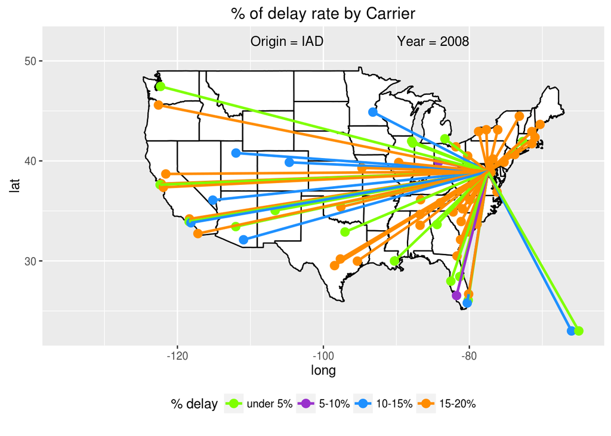

```r
  IAD_map2 = getMap("IAD", 2008, arrDelay = TRUE)
  print(IAD_map2$map)
```

뉴욕과달리 IAD는 departure delay에서 지연시간이 길다. 반면 arrival delay에서는 그 양상이 덜하다.

## 지도당 소요시간

```r
  time = c(EWR_map1$timesTaken, EWR_map2$timesTaken, JFK_map1$timesTaken,
           JFK_map2$timesTaken, IAD_map1$timesTaken, IAD_map2$timesTaken)
  print( paste('EWR ~ IAD 각각의 소요시간', round(time,3), "초") )
```

```
## [1] "EWR ~ IAD 각각의 소요시간 27.419 초"
## [2] "EWR ~ IAD 각각의 소요시간 20.096 초"
## [3] "EWR ~ IAD 각각의 소요시간 18.691 초"
## [4] "EWR ~ IAD 각각의 소요시간 18.67 초"
## [5] "EWR ~ IAD 각각의 소요시간 18.535 초"
## [6] "EWR ~ IAD 각각의 소요시간 18.391 초"
```